# University of Niagara Falls, Canada

## Master's Data Analytics

### Spring 2025 Data Analytics Case Study 3 (DAMO-611-6)

### Group 6

- Atuchukwu, Victor Emmanuel Somtochukwu
- Maharaj, Avinash Brandon
- Ritu, Ritu
- Zamudio Portilla, Mario Fernando

### Case Study Part 1

May 24th, 2025

#### Dataset:

World Export & Import Dataset (1989 - 2023)

#### Source:

https://www.kaggle.com/datasets/muhammadtalhaawan/world-export-and-import-dataset

#### Phase 1: Problem Definition, Research Question, Hypothesis Formulation, Data Collection

- Clear definition of the problem statement related to business analytics.
- Well-defined research question that aligns with the problem statement.
- Justification of the relevance and importance of the research.
- Clear formulation of hypotheses related to the research question.
- Hypotheses are specific, testable, and relevant to the problem under investigation.
- Utilization of appropriate SQL commands to extract relevant data from different tables.

#### Phase 2 and 3: Data Understanding and Data Visualization:

- Thorough exploration and analysis of the collected data.
- Identification of key metrics, trends, and patterns relevant to the research question.
- Clear interpretation of findings and insights derived from the data analysis.
- Effective use of data visualization techniques to represent analyzed data.
- Creation of clear and insightful charts, graphs, and dashboards.

##### Problem Statement:

Global trade plays a crucial role in the economic development of countries. However, understanding the patterns and trends in export and import activities over time is a complex challenge due to the volume and diversity of trade data. Businesses and policymakers require actionable insights into the evolution of international trade flows to make informed decisions on market entry, risk management, and policy formulation.

This project aims to analyze 34 years of world export and import data to identify key trends, emerging markets, and the impact of global events on trade volumes. The ultimate goal is to provide strategic recommendations for businesses and governments to optimize their trade strategies and improve competitiveness in the global market.

### Libraries Importation

```python
# Import pandas library for data manipulation and analysis
import pandas as pd
# Import numpy library for numerical operations
import numpy as np
# Import matplotlib.pyplot for creating visualizations and plots
import matplotlib.pyplot as plt
# Import seaborn library for statistical data visualization
import seaborn as sns
# Import numpy library for numerical operations (note: this is a duplicate import)
import numpy as np
# Import statistical functions from scipy
from scipy import stats
# Import statsmodels for statistical models and tests
import statsmodels.api as sm
# Import ticker module from matplotlib for customizing axis tick labels and formatting
import matplotlib.ticker as mticker
```

### Import Dataset and Initial Exploration

```python
# Load the world export-import dataset from a CSV file into a pandas DataFrame
dts_export_import = pd.read_csv('34_years_world_export_import_dataset.csv')
dts_export_import
```

|  | Partner Name | Year | Export (US$ Thousand) | Import (US$ Thousand) | Export Product Share (%) | Import Product Share (%) | Revealed comparative advantage | World Growth (%) | Country Growth (%) | AHS Simple Average (%) | ... | MFN Total Tariff Lines | MFN Dutiable Tariff Lines Share (%) | MFN Duty Free Tariff Lines Share (%) | MFN Specific Tariff Lines Share (%) | MFN AVE Tariff Lines Share (%) | MFN MaxRate (%) | MFN MinRate (%) | MFN SpecificDuty Imports (US$ Thousand) | MFN Dutiable Imports (US$ Thousand) | MFN Duty Free Imports (US$ Thousand) |
| --- | --- | --- | --- | --- | --- | --- | --- | --- | --- | --- | --- | --- | --- | --- | --- | --- | --- | --- | --- | --- | --- |
| 0 | Aruba | 1988 | 3.498100e+03 | 3.284900e+02 | 100.0 | 100 | NaN | NaN | NaN | 2.80 | ... | 1152.0 | 63.54 | 22.74 | 70.32 | 31.61 | 352.69 | 0.0 | 2.186000e+03 | 3.128020e+03 | 0.00 |
| 1 | Afghanistan | 1988 | 2.130304e+05 | 5.445952e+04 | 100.0 | 100 | NaN | NaN | NaN | 0.88 | ... | 4142.0 | 69.41 | 15.64 | 72.45 | 40.51 | 2029.66 | 0.0 | 7.843691e+04 | 9.419150e+04 | 0.00 |
| 2 | Angola | 1988 | 3.755279e+05 | 3.707028e+05 | 100.0 | 100 | NaN | NaN | NaN | 2.02 | ... | 5438.0 | 76.00 | 16.27 | 41.55 | 24.80 | 451.15 | 0.0 | 7.277420e+05 | 9.214815e+05 | 0.00 |
| 3 | Anguila | 1988 | 3.669800e+02 | 4.000000e+00 | 100.0 | 100 | NaN | NaN | NaN | 3.71 | ... | 322.0 | 66.15 | 22.05 | 78.79 | 36.36 | 100.00 | 0.0 | 9.400000e+01 | 5.830000e+02 | 0.00 |
| 4 | Albania | 1988 | 3.010356e+04 | 4.770930e+04 | 100.0 | 100 | NaN | NaN | NaN | 1.84 | ... | 5684.0 | 66.87 | 19.19 | 57.93 | 48.52 | 3000.00 | 0.0 | 3.790409e+04 | 1.011959e+05 | 0.00 |
| ... | ... | ... | ... | ... | ... | ... | ... | ... | ... | ... | ... | ... | ... | ... | ... | ... | ... | ... | ... | ... | ... |
| 8091 | Latin America & Caribbean | 2021 | 1.330557e+09 | 1.310305e+09 | 100.0 | 100 | NaN | NaN | NaN | 3.84 | ... | 1509731.0 | 67.97 | 25.91 | 0.39 | 5.08 | 3000.00 | 0.0 | 4.193397e+08 | 1.346740e+09 | 1632.05 |
| 8092 | Middle East & North Africa | 2021 | 1.196712e+09 | 1.088471e+09 | 100.0 | 100 | NaN | NaN | NaN | 4.63 | ... | 1507304.0 | 67.98 | 25.91 | 0.46 | 5.92 | 3000.00 | 0.0 | 5.809079e+08 | 1.117309e+09 | 0.00 |
| 8093 | North America | 2021 | 3.823319e+09 | 2.219849e+09 | 100.0 | 100 | NaN | NaN | NaN | 6.45 | ... | 1533357.0 | 67.86 | 26.04 | 0.59 | 7.58 | 3000.00 | 0.0 | 6.433132e+08 | 2.055953e+09 | 23691.96 |
| 8094 | South Asia | 2021 | 6.991380e+08 | 4.723832e+08 | 100.0 | 100 | NaN | NaN | NaN | 5.09 | ... | 1508290.0 | 67.94 | 26.02 | 0.68 | 8.71 | 3000.00 | 0.0 | 8.497724e+07 | 5.123190e+08 | 0.05 |
| 8095 | Sub-Saharan Africa | 2021 | 4.951000e+08 | 4.350468e+08 | 100.0 | 100 | NaN | NaN | NaN | 3.22 | ... | 1513840.0 | 67.92 | 25.93 | 0.70 | 8.99 | 3000.00 | 0.0 | 2.234618e+08 | 4.915992e+08 | 2.83 |

8096 rows × 33 columns

```python
# Get the dimensions of the dataset (number of rows and columns)
dts_export_import.shape
```

```
(8096, 33)
```

```python
# Print information about the dataframe including data types and non-null values
print(dts_export_import.info())
# Generate descriptive statistics of the dataframe (count, mean, std, min, 25%, 50%, 75%, max)
print(dts_export_import.describe())
```

```
<class 'pandas.core.frame.DataFrame'>
RangeIndex: 8096 entries, 0 to 8095
Data columns (total 33 columns):
 #   Column                                   Non-Null Count  Dtype
---  ------                                   --------------  -----
 0   Partner Name                             8096 non-null   object
 1   Year                                     8096 non-null   int64
 2   Export (US$ Thousand)                    8096 non-null   float64
 3   Import (US$ Thousand)                    8096 non-null   float64
 4   Export Product Share (%)                 8076 non-null   float64
 5   Import Product Share (%)                 8096 non-null   int64
 6   Revealed comparative advantage           4712 non-null   float64
 7   World Growth (%)                         4410 non-null   float64
 8   Country Growth (%)                       4410 non-null   float64
 9   AHS Simple Average (%)                   8080 non-null   float64
 10  AHS Weighted Average (%)                 8080 non-null   float64
 11  AHS Total Tariff Lines                   8080 non-null   float64
 12  AHS Dutiable Tariff Lines Share (%)      8080 non-null   float64
 13  AHS Duty Free Tariff Lines Share (%)     8080 non-null   float64
 14  AHS Specific Tariff Lines Share (%)      8080 non-null   float64
 15  AHS AVE Tariff Lines Share (%)           8080 non-null   float64
 16  AHS MaxRate (%)                          8080 non-null   float64
 17  AHS MinRate (%)                          8080 non-null   float64
 18  AHS SpecificDuty Imports (US$ Thousand)  8081 non-null   float64
 19  AHS Dutiable Imports (US$ Thousand)      8081 non-null   float64
 20  AHS Duty Free Imports (US$ Thousand)     8081 non-null   float64
 21  MFN Simple Average (%)                   8081 non-null   float64
 22  MFN Weighted Average (%)                 8081 non-null   float64
 23  MFN Total Tariff Lines                   8081 non-null   float64
 24  MFN Dutiable Tariff Lines Share (%)      8081 non-null   float64
 25  MFN Duty Free Tariff Lines Share (%)     8081 non-null   float64
 26  MFN Specific Tariff Lines Share (%)      8080 non-null   float64
 27  MFN AVE Tariff Lines Share (%)           8080 non-null   float64
 28  MFN MaxRate (%)                          8081 non-null   float64
 29  MFN MinRate (%)                          8081 non-null   float64
 30  MFN SpecificDuty Imports (US$ Thousand)  8081 non-null   float64
 31  MFN Dutiable Imports (US$ Thousand)      8081 non-null   float64
 32  MFN Duty Free Imports (US$ Thousand)     8081 non-null   float64
dtypes: float64(30), int64(2), object(1)
memory usage: 2.0+ MB
```

[output cut: 97 more lines]

```
50%                           2.048332e+06
75%                           1.717688e+07
max                           1.854956e+10

       MFN Duty Free Imports (US$ Thousand)
count                          8.081000e+03
mean                           1.058794e+05
std                            4.178933e+06
min                            0.000000e+00
25%                            0.000000e+00
50%                            0.000000e+00
75%                            0.000000e+00
max                            3.495531e+08

[8 rows x 32 columns]
```

### Cleaning Data

```python
# Calculate the sum of missing values (NaN) for each column in the dts_export_import dataframe
missing_values = dts_export_import.isnull().sum()
# Display the count of missing values for each column
missing_values
```

```
Partner Name                                  0
Year                                          0
Export (US$ Thousand)                         0
Import (US$ Thousand)                         0
Export Product Share (%)                     20
Import Product Share (%)                      0
Revealed comparative advantage             3384
World Growth (%)                           3686
Country Growth (%)                         3686
AHS Simple Average (%)                       16
AHS Weighted Average (%)                     16
AHS Total Tariff Lines                       16
AHS Dutiable Tariff Lines Share (%)          16
AHS Duty Free Tariff Lines Share (%)         16
AHS Specific Tariff Lines Share (%)          16
AHS AVE Tariff Lines Share (%)               16
AHS MaxRate (%)                              16
AHS MinRate (%)                              16
AHS SpecificDuty Imports (US$ Thousand)      15
AHS Dutiable Imports (US$ Thousand)          15
AHS Duty Free Imports (US$ Thousand)         15
MFN Simple Average (%)                       15
MFN Weighted Average (%)                     15
MFN Total Tariff Lines                       15
MFN Dutiable Tariff Lines Share (%)          15
MFN Duty Free Tariff Lines Share (%)         15
MFN Specific Tariff Lines Share (%)          16
MFN AVE Tariff Lines Share (%)               16
MFN MaxRate (%)                              15
MFN MinRate (%)                              15
MFN SpecificDuty Imports (US$ Thousand)      15
MFN Dutiable Imports (US$ Thousand)          15
MFN Duty Free Imports (US$ Thousand)         15
dtype: int64
```

```python
# Calculate the total number of data points in the dataset (rows × columns)
total_dataset = np.product(dts_export_import.shape)
# Count the total number of missing values in the dataset
total_missing = missing_values.sum()
# Calculate the percentage of missing values in the dataset
percent = (total_missing / total_dataset) * 100
# Display the percentage of missing values
percent
```

```
4.172281111510361
```

```python
### Crating Working Dataset
```

```python
# Create a dataset with the key parameters to review and explore the information
Trade_Dataset = dts_export_import[['Partner Name',
'Year',
'Export (US$ Thousand)',
'Import (US$ Thousand)',
'AHS Simple Average (%)',
'AHS Weighted Average (%)',
'AHS Total Tariff Lines',
'AHS Dutiable Imports (US$ Thousand)',
'AHS Duty Free Imports (US$ Thousand)',
'MFN Simple Average (%)',
'MFN Weighted Average (%)',
'MFN Total Tariff Lines',
'MFN Dutiable Imports (US$ Thousand)',
'MFN Duty Free Imports (US$ Thousand)']].copy()

Trade_Dataset['Trade Balance'] = Trade_Dataset['Export (US$ Thousand)'] - Trade_Dataset['Import (US$ Thousand)']
Trade_Dataset['Trade Total'] = Trade_Dataset['Export (US$ Thousand)'] + Trade_Dataset['Import (US$ Thousand)']

Trade_Dataset
```

|  | Partner Name | Year | Export (US$ Thousand) | Import (US$ Thousand) | AHS Simple Average (%) | AHS Weighted Average (%) | AHS Total Tariff Lines | AHS Dutiable Imports (US$ Thousand) | AHS Duty Free Imports (US$ Thousand) | MFN Simple Average (%) | MFN Weighted Average (%) | MFN Total Tariff Lines | MFN Dutiable Imports (US$ Thousand) | MFN Duty Free Imports (US$ Thousand) | Trade Balance | Trade Total |
| --- | --- | --- | --- | --- | --- | --- | --- | --- | --- | --- | --- | --- | --- | --- | --- | --- |
| 0 | Aruba | 1988 | 3.498100e+03 | 3.284900e+02 | 2.80 | 2.92 | 155.0 | 2.346370e+03 | 781.65 | 13.59 | 8.46 | 1152.0 | 3.128020e+03 | 0.00 | 3.169610e+03 | 3.826590e+03 |
| 1 | Afghanistan | 1988 | 2.130304e+05 | 5.445952e+04 | 0.88 | 1.83 | 548.0 | 7.020413e+04 | 23987.37 | 17.68 | 12.43 | 4142.0 | 9.419150e+04 | 0.00 | 1.585709e+05 | 2.674899e+05 |
| 2 | Angola | 1988 | 3.755279e+05 | 3.707028e+05 | 2.02 | 3.89 | 633.0 | 7.541838e+05 | 167297.68 | 12.70 | 6.14 | 5438.0 | 9.214815e+05 | 0.00 | 4.825130e+03 | 7.462307e+05 |
| 3 | Anguila | 1988 | 3.669800e+02 | 4.000000e+00 | 3.71 | 1.09 | 33.0 | 6.500000e+01 | 518.00 | 16.63 | 14.75 | 322.0 | 5.830000e+02 | 0.00 | 3.629800e+02 | 3.709800e+02 |
| 4 | Albania | 1988 | 3.010356e+04 | 4.770930e+04 | 1.84 | 2.38 | 744.0 | 6.229453e+04 | 38901.42 | 19.20 | 9.68 | 5684.0 | 1.011959e+05 | 0.00 | -1.760574e+04 | 7.781286e+04 |
| ... | ... | ... | ... | ... | ... | ... | ... | ... | ... | ... | ... | ... | ... | ... | ... | ... |
| 8091 | Latin America & Caribbean | 2021 | 1.330557e+09 | 1.310305e+09 | 3.84 | 6.71 | 1688963.0 | 1.339963e+09 | 6778449.31 | 8.77 | 9.32 | 1509731.0 | 1.346740e+09 | 1632.05 | 2.025145e+07 | 2.640862e+09 |
| 8092 | Middle East & North Africa | 2021 | 1.196712e+09 | 1.088471e+09 | 4.63 | 2.14 | 1445742.0 | 1.116203e+09 | 1105646.72 | 8.56 | 4.29 | 1507304.0 | 1.117309e+09 | 0.00 | 1.082410e+08 | 2.285184e+09 |
| 8093 | North America | 2021 | 3.823319e+09 | 2.219849e+09 | 6.45 | 4.63 | 1144964.0 | 2.053437e+09 | 2539310.69 | 8.92 | 6.30 | 1533357.0 | 2.055953e+09 | 23691.96 | 1.603469e+09 | 6.043168e+09 |
| 8094 | South Asia | 2021 | 6.991380e+08 | 4.723832e+08 | 5.09 | 5.96 | 969270.0 | 5.109348e+08 | 1384185.04 | 8.50 | 9.84 | 1508290.0 | 5.123190e+08 | 0.05 | 2.267548e+08 | 1.171521e+09 |
| 8095 | Sub-Saharan Africa | 2021 | 4.951000e+08 | 4.350468e+08 | 3.22 | 1.82 | 961981.0 | 4.907281e+08 | 871108.71 | 8.60 | 5.41 | 1513840.0 | 4.915992e+08 | 2.83 | 6.005324e+07 | 9.301468e+08 |

8096 rows × 16 columns

```python
# Check the dimensions of the Trade_Dataset DataFrame
Trade_Dataset.shape
```

```
(8096, 16)
```

### Preprocesing Data

```python
# Cleaning duplicates
Trade_Dataset = Trade_Dataset.drop_duplicates()
# Check the dimensions of the Trade_Dataset DataFrame
Trade_Dataset.shape
```

```
(8096, 16)
```

```python
# Calculate the sum of missing values (NaN) for each column in the dts_export_import dataframe
missing_values = Trade_Dataset.isnull().sum()
# Display the count of missing values for each column
missing_values
```

```
Partner Name                             0
Year                                     0
Export (US$ Thousand)                    0
Import (US$ Thousand)                    0
AHS Simple Average (%)                  16
AHS Weighted Average (%)                16
AHS Total Tariff Lines                  16
AHS Dutiable Imports (US$ Thousand)     15
AHS Duty Free Imports (US$ Thousand)    15
MFN Simple Average (%)                  15
MFN Weighted Average (%)                15
MFN Total Tariff Lines                  15
MFN Dutiable Imports (US$ Thousand)     15
MFN Duty Free Imports (US$ Thousand)    15
Trade Balance                            0
Trade Total                              0
dtype: int64
```

```python
# Remove rows with missing values (NaN) from the Trade_Dataset dataframe
Trade_Dataset = Trade_Dataset.dropna()
```

```python
# Calculate the sum of missing values (NaN) for each column in the dts_export_import dataframe
missing_values = Trade_Dataset.isnull().sum()
# Display the count of missing values for each column
missing_values
```

```
Partner Name                            0
Year                                    0
Export (US$ Thousand)                   0
Import (US$ Thousand)                   0
AHS Simple Average (%)                  0
AHS Weighted Average (%)                0
AHS Total Tariff Lines                  0
AHS Dutiable Imports (US$ Thousand)     0
AHS Duty Free Imports (US$ Thousand)    0
MFN Simple Average (%)                  0
MFN Weighted Average (%)                0
MFN Total Tariff Lines                  0
MFN Dutiable Imports (US$ Thousand)     0
MFN Duty Free Imports (US$ Thousand)    0
Trade Balance                           0
Trade Total                             0
dtype: int64
```

```python
# Check the dimensions of the Trade_Dataset DataFrame
Trade_Dataset.shape
```

```
(8080, 16)
```

```python
# Check the data types of all columns in the Trade_Dataset DataFrame
# This helps understand what kind of data each column contains (e.g., integers, floats, strings)
Trade_Dataset.dtypes
```

```
Partner Name                             object
Year                                      int64
Export (US$ Thousand)                   float64
Import (US$ Thousand)                   float64
AHS Simple Average (%)                  float64
AHS Weighted Average (%)                float64
AHS Total Tariff Lines                  float64
AHS Dutiable Imports (US$ Thousand)     float64
AHS Duty Free Imports (US$ Thousand)    float64
MFN Simple Average (%)                  float64
MFN Weighted Average (%)                float64
MFN Total Tariff Lines                  float64
MFN Dutiable Imports (US$ Thousand)     float64
MFN Duty Free Imports (US$ Thousand)    float64
Trade Balance                           float64
Trade Total                             float64
dtype: object
```

### Data Visualization

[figure not shown]

```python
# Plotting Export and Import Trends Over Time
filtered_data = Trade_Dataset[Trade_Dataset['Partner Name'] != ' World']
world_data = Trade_Dataset[Trade_Dataset['Partner Name'] == ' World']
yearly_world = world_data.groupby('Year')[['Export (US$ Thousand)', 'Import (US$ Thousand)', 'Trade Balance', 'Trade Total']].sum().reset_index()

plt.figure(figsize=(12, 6))
plt.plot(yearly_world['Year'], yearly_world['Export (US$ Thousand)'], label='Total World Imports')
plt.plot(yearly_world['Year'], yearly_world['Import (US$ Thousand)'], label='Total World Imports')
plt.plot(yearly_world['Year'], yearly_world['Trade Balance'], label='Total World Trade Balance')
plt.plot(yearly_world['Year'], yearly_world['Trade Total'], label='Total World Trade')
plt.xlabel('Year')
plt.ylabel('Trade Value (US$)')
plt.title('Global Export and Import Trends (1980-2013)')
plt.legend()
plt.grid(True)
plt.show()
```

```python
# Top countries by export/import
top_exporters = filtered_data.groupby('Partner Name')['Export (US$ Thousand)'].sum().sort_values(ascending=False).head(10)
print("\nTop 10 Exporting Countries (Total over 34 years):")
print(top_exporters)

top_importers = filtered_data.groupby('Partner Name')['Import (US$ Thousand)'].sum().sort_values(ascending=False).head(10)
print("\nTop 10 Importing Countries (Total over 34 years):")
print(top_importers)

top_balance = filtered_data.groupby('Partner Name')['Trade Balance'].sum().sort_values(ascending=False).head(10)
print("\nTop 10 Trade Balance Countries (Total over 34 years):")
print(top_balance)

top_trade = filtered_data.groupby('Partner Name')['Trade Total'].sum().sort_values(ascending=False).head(10)
print("\nTop 10 Trade Total Countries (Total over 34 years):")
print(top_trade)
```

```
Top 10 Exporting Countries (Total over 34 years):
Partner Name
Europe & Central Asia         1.500154e+11
East Asia & Pacific           9.443141e+10
North America                 6.530151e+10
United States                 5.495734e+10
China                         2.826862e+10
Germany                       2.329030e+10
Latin America & Caribbean     2.155302e+10
Middle East & North Africa    2.062328e+10
United Kingdom                1.510597e+10
Japan                         1.453045e+10
Name: Export (US$ Thousand), dtype: float64

Top 10 Importing Countries (Total over 34 years):
Partner Name
Europe & Central Asia         1.388943e+11
East Asia & Pacific           1.062229e+11
North America                 4.311681e+10
China                         4.246660e+10
United States                 3.268715e+10
Germany                       2.848006e+10
Latin America & Caribbean     2.125695e+10
Middle East & North Africa    2.009109e+10
Japan                         1.943478e+10
France                        1.321301e+10
Name: Import (US$ Thousand), dtype: float64

Top 10 Trade Balance Countries (Total over 34 years):
Partner Name
United States            2.227019e+10
North America            2.218469e+10
Europe & Central Asia    1.112111e+10
Hong Kong, China         1.038343e+10
Unspecified              7.339505e+09
United Kingdom           4.615490e+09
Switzerland              2.670832e+09
South Asia               2.561655e+09
Turkey                   2.443434e+09
Netherlands              2.096898e+09
Name: Trade Balance, dtype: float64

Top 10 Trade Total Countries (Total over 34 years):
Partner Name
Europe & Central Asia         2.889098e+11
East Asia & Pacific           2.006543e+11
North America                 1.084183e+11
United States                 8.764450e+10
China                         7.073522e+10
Germany                       5.177036e+10
Latin America & Caribbean     4.280997e+10
Middle East & North Africa    4.071438e+10
Japan                         3.396523e+10
France                        2.744588e+10
Name: Trade Total, dtype: float64
```

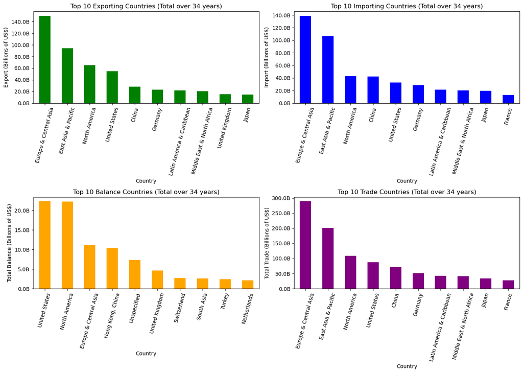

```python
# Create a figure with four subplots
fig, axes = plt.subplots(2, 2, figsize=(14, 10))
ax1, ax2, ax3, ax4 = axes.flatten()

# Function to format y-axis ticks in billions (e.g., 2.5B)
def billions(x, pos):
    return f'{x * 1e-9:.1f}B'

# Plot top exporters
top_exporters.plot(kind='bar', ax=ax1, color='green')
ax1.set_title('Top 10 Exporting Countries (Total over 34 years)')
ax1.set_ylabel('Export (Billions of US$)')
ax1.set_xlabel('Country')
ax1.yaxis.set_major_formatter(mticker.FuncFormatter(billions))
ax1.tick_params(axis='x', rotation=75)

# Plot top importers
top_importers.plot(kind='bar', ax=ax2, color='blue')
ax2.set_title('Top 10 Importing Countries (Total over 34 years)')
ax2.set_ylabel('Import (Billions of US$)')
ax2.set_xlabel('Country')
ax2.yaxis.set_major_formatter(mticker.FuncFormatter(billions))
ax2.tick_params(axis='x', rotation=75)

# Plot top balance
top_balance.plot(kind='bar', ax=ax3, color='orange')
ax3.set_title('Top 10 Balance Countries (Total over 34 years)')
ax3.set_ylabel('Total Balance (Billions of US$)')
ax3.set_xlabel('Country')
ax3.yaxis.set_major_formatter(mticker.FuncFormatter(billions))
ax3.tick_params(axis='x', rotation=75)

# Plot top trade
top_trade.plot(kind='bar', ax=ax4, color='purple')
ax4.set_title('Top 10 Trade Countries (Total over 34 years)')
ax4.set_ylabel('Total Trade (Billions of US$)')
ax4.set_xlabel('Country')
ax4.yaxis.set_major_formatter(mticker.FuncFormatter(billions))
ax4.tick_params(axis='x', rotation=75)

plt.tight_layout()
plt.show()
```

```python
### Findings in the information
```

```python
# From the last calculations and graphs, the values for imports and exports seem inverted.
# We review the source and we found a error in the generation of the data, for this reason we interchange the
# columns names
# Create a mapping for swapping column names
swap_dict = {
    'Export (US$ Thousand)': 'Import (US$ Thousand)',
    'Import (US$ Thousand)': 'Export (US$ Thousand)'
}

# Temporarily rename to avoid conflicts, then assign back the original names swapped
Trade_Dataset = Trade_Dataset.rename(columns={
    'Export (US$ Thousand)': 'TEMP_EXPORT',
    'Import (US$ Thousand)': 'Export (US$ Thousand)'
})
Trade_Dataset = Trade_Dataset.rename(columns={
    'TEMP_EXPORT': 'Import (US$ Thousand)'
})
```

```python
Trade_Dataset
```

|  | Partner Name | Year | Import (US$ Thousand) | Export (US$ Thousand) | AHS Simple Average (%) | AHS Weighted Average (%) | AHS Total Tariff Lines | AHS Dutiable Imports (US$ Thousand) | AHS Duty Free Imports (US$ Thousand) | MFN Simple Average (%) | MFN Weighted Average (%) | MFN Total Tariff Lines | MFN Dutiable Imports (US$ Thousand) | MFN Duty Free Imports (US$ Thousand) | Trade Balance | Trade Total |
| --- | --- | --- | --- | --- | --- | --- | --- | --- | --- | --- | --- | --- | --- | --- | --- | --- |
| 0 | Aruba | 1988 | 3.498100e+03 | 3.284900e+02 | 2.80 | 2.92 | 155.0 | 2.346370e+03 | 781.65 | 13.59 | 8.46 | 1152.0 | 3.128020e+03 | 0.00 | 3.169610e+03 | 3.826590e+03 |
| 1 | Afghanistan | 1988 | 2.130304e+05 | 5.445952e+04 | 0.88 | 1.83 | 548.0 | 7.020413e+04 | 23987.37 | 17.68 | 12.43 | 4142.0 | 9.419150e+04 | 0.00 | 1.585709e+05 | 2.674899e+05 |
| 2 | Angola | 1988 | 3.755279e+05 | 3.707028e+05 | 2.02 | 3.89 | 633.0 | 7.541838e+05 | 167297.68 | 12.70 | 6.14 | 5438.0 | 9.214815e+05 | 0.00 | 4.825130e+03 | 7.462307e+05 |
| 3 | Anguila | 1988 | 3.669800e+02 | 4.000000e+00 | 3.71 | 1.09 | 33.0 | 6.500000e+01 | 518.00 | 16.63 | 14.75 | 322.0 | 5.830000e+02 | 0.00 | 3.629800e+02 | 3.709800e+02 |
| 4 | Albania | 1988 | 3.010356e+04 | 4.770930e+04 | 1.84 | 2.38 | 744.0 | 6.229453e+04 | 38901.42 | 19.20 | 9.68 | 5684.0 | 1.011959e+05 | 0.00 | -1.760574e+04 | 7.781286e+04 |
| ... | ... | ... | ... | ... | ... | ... | ... | ... | ... | ... | ... | ... | ... | ... | ... | ... |
| 8091 | Latin America & Caribbean | 2021 | 1.330557e+09 | 1.310305e+09 | 3.84 | 6.71 | 1688963.0 | 1.339963e+09 | 6778449.31 | 8.77 | 9.32 | 1509731.0 | 1.346740e+09 | 1632.05 | 2.025145e+07 | 2.640862e+09 |
| 8092 | Middle East & North Africa | 2021 | 1.196712e+09 | 1.088471e+09 | 4.63 | 2.14 | 1445742.0 | 1.116203e+09 | 1105646.72 | 8.56 | 4.29 | 1507304.0 | 1.117309e+09 | 0.00 | 1.082410e+08 | 2.285184e+09 |
| 8093 | North America | 2021 | 3.823319e+09 | 2.219849e+09 | 6.45 | 4.63 | 1144964.0 | 2.053437e+09 | 2539310.69 | 8.92 | 6.30 | 1533357.0 | 2.055953e+09 | 23691.96 | 1.603469e+09 | 6.043168e+09 |
| 8094 | South Asia | 2021 | 6.991380e+08 | 4.723832e+08 | 5.09 | 5.96 | 969270.0 | 5.109348e+08 | 1384185.04 | 8.50 | 9.84 | 1508290.0 | 5.123190e+08 | 0.05 | 2.267548e+08 | 1.171521e+09 |
| 8095 | Sub-Saharan Africa | 2021 | 4.951000e+08 | 4.350468e+08 | 3.22 | 1.82 | 961981.0 | 4.907281e+08 | 871108.71 | 8.60 | 5.41 | 1513840.0 | 4.915992e+08 | 2.83 | 6.005324e+07 | 9.301468e+08 |

8080 rows × 16 columns

[figure not shown]

```python
# Plotting Export and Import Trends Over Time
filtered_data = Trade_Dataset[Trade_Dataset['Partner Name'] != ' World']
world_data = Trade_Dataset[Trade_Dataset['Partner Name'] == ' World']
yearly_world = world_data.groupby('Year')[['Export (US$ Thousand)', 'Import (US$ Thousand)', 'Trade Balance', 'Trade Total']].sum().reset_index()

plt.figure(figsize=(12, 6))
plt.plot(yearly_world['Year'], yearly_world['Export (US$ Thousand)'], label='Total World Imports')
plt.plot(yearly_world['Year'], yearly_world['Import (US$ Thousand)'], label='Total World Imports')
plt.plot(yearly_world['Year'], yearly_world['Trade Balance'], label='Total World Trade Balance')
plt.plot(yearly_world['Year'], yearly_world['Trade Total'], label='Total World Trade')
plt.xlabel('Year')
plt.ylabel('Trade Value (US$)')
plt.title('Global Export and Import Trends (1980-2013)')
plt.legend()
plt.grid(True)
plt.show()
```

```python
# Top countries by export/import
top_exporters = filtered_data.groupby('Partner Name')['Export (US$ Thousand)'].sum().sort_values(ascending=False).head(10)
print("\nTop 10 Exporting Countries (Total over 34 years):")
print(top_exporters)

top_importers = filtered_data.groupby('Partner Name')['Import (US$ Thousand)'].sum().sort_values(ascending=False).head(10)
print("\nTop 10 Importing Countries (Total over 34 years):")
print(top_importers)

top_balance = filtered_data.groupby('Partner Name')['Trade Balance'].sum().sort_values(ascending=False).head(10)
print("\nTop 10 Trade Balance Countries (Total over 34 years):")
print(top_balance)

top_trade = filtered_data.groupby('Partner Name')['Trade Total'].sum().sort_values(ascending=False).head(10)
print("\nTop 10 Trade Total Countries (Total over 34 years):")
print(top_trade)
```

```
Top 10 Exporting Countries (Total over 34 years):
Partner Name
Europe & Central Asia         1.388943e+11
East Asia & Pacific           1.062229e+11
North America                 4.311681e+10
China                         4.246660e+10
United States                 3.268715e+10
Germany                       2.848006e+10
Latin America & Caribbean     2.125695e+10
Middle East & North Africa    2.009109e+10
Japan                         1.943478e+10
France                        1.321301e+10
Name: Export (US$ Thousand), dtype: float64

Top 10 Importing Countries (Total over 34 years):
Partner Name
Europe & Central Asia         1.500154e+11
East Asia & Pacific           9.443141e+10
North America                 6.530151e+10
United States                 5.495734e+10
China                         2.826862e+10
Germany                       2.329030e+10
Latin America & Caribbean     2.155302e+10
Middle East & North Africa    2.062328e+10
United Kingdom                1.510597e+10
Japan                         1.453045e+10
Name: Import (US$ Thousand), dtype: float64

Top 10 Trade Balance Countries (Total over 34 years):
Partner Name
United States            2.227019e+10
North America            2.218469e+10
Europe & Central Asia    1.112111e+10
Hong Kong, China         1.038343e+10
Unspecified              7.339505e+09
United Kingdom           4.615490e+09
Switzerland              2.670832e+09
South Asia               2.561655e+09
Turkey                   2.443434e+09
Netherlands              2.096898e+09
Name: Trade Balance, dtype: float64

Top 10 Trade Total Countries (Total over 34 years):
Partner Name
Europe & Central Asia         2.889098e+11
East Asia & Pacific           2.006543e+11
North America                 1.084183e+11
United States                 8.764450e+10
China                         7.073522e+10
Germany                       5.177036e+10
Latin America & Caribbean     4.280997e+10
Middle East & North Africa    4.071438e+10
Japan                         3.396523e+10
France                        2.744588e+10
Name: Trade Total, dtype: float64
```

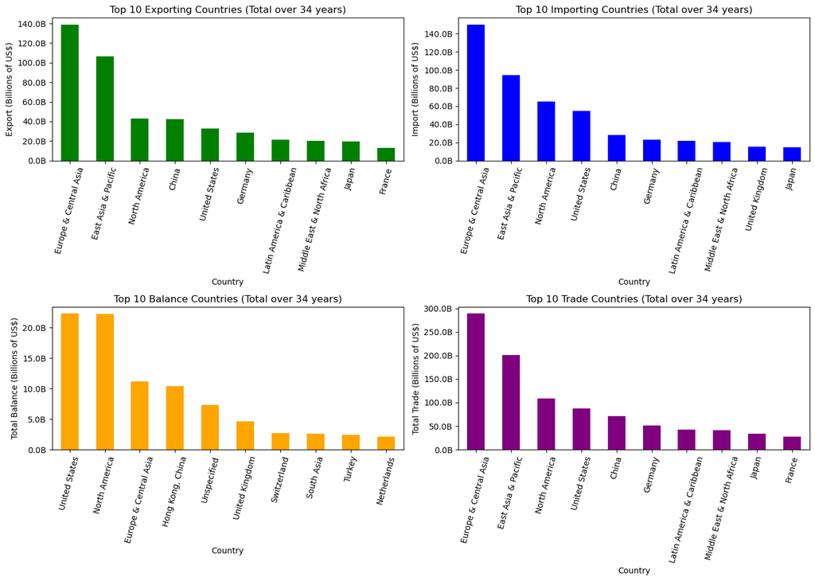

```python
# Create a figure with four subplots
fig, axes = plt.subplots(2, 2, figsize=(14, 10))
ax1, ax2, ax3, ax4 = axes.flatten()

# Function to format y-axis ticks in billions (e.g., 2.5B)
def billions(x, pos):
    return f'{x * 1e-9:.1f}B'

# Plot top exporters
top_exporters.plot(kind='bar', ax=ax1, color='green')
ax1.set_title('Top 10 Exporting Countries (Total over 34 years)')
ax1.set_ylabel('Export (Billions of US$)')
ax1.set_xlabel('Country')
ax1.yaxis.set_major_formatter(mticker.FuncFormatter(billions))
ax1.tick_params(axis='x', rotation=75)

# Plot top importers
top_importers.plot(kind='bar', ax=ax2, color='blue')
ax2.set_title('Top 10 Importing Countries (Total over 34 years)')
ax2.set_ylabel('Import (Billions of US$)')
ax2.set_xlabel('Country')
ax2.yaxis.set_major_formatter(mticker.FuncFormatter(billions))
ax2.tick_params(axis='x', rotation=75)

# Plot top balance
top_balance.plot(kind='bar', ax=ax3, color='orange')
ax3.set_title('Top 10 Balance Countries (Total over 34 years)')
ax3.set_ylabel('Total Balance (Billions of US$)')
ax3.set_xlabel('Country')
ax3.yaxis.set_major_formatter(mticker.FuncFormatter(billions))
ax3.tick_params(axis='x', rotation=75)

# Plot top trade
top_trade.plot(kind='bar', ax=ax4, color='purple')
ax4.set_title('Top 10 Trade Countries (Total over 34 years)')
ax4.set_ylabel('Total Trade (Billions of US$)')
ax4.set_xlabel('Country')
ax4.yaxis.set_major_formatter(mticker.FuncFormatter(billions))
ax4.tick_params(axis='x', rotation=75)

plt.tight_layout()
plt.show()
```

### Trends in the information

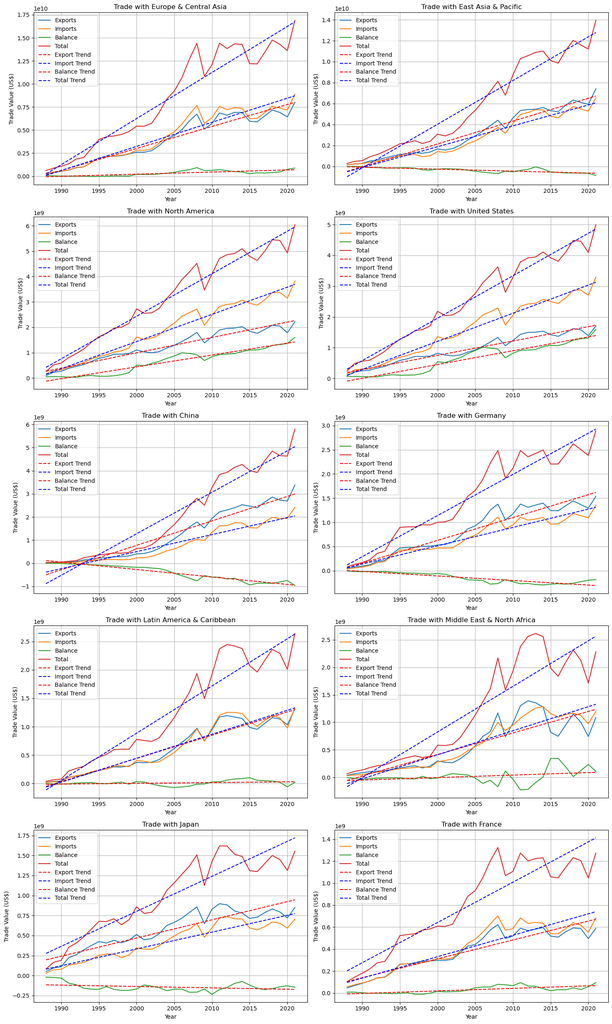

```python
# Identify top 5 trading partners by total trade volume
partner_totals = filtered_data.groupby('Partner Name')[['Export (US$ Thousand)', 'Import (US$ Thousand)', 'Trade Balance', 'Trade Total']].sum()

top_10_partners = partner_totals.nlargest(10, 'Trade Total').index.tolist()

# Create a figure with subplots
fig, axes = plt.subplots(5, 2, figsize=(15, 25))
axes = axes.flatten()

# Plot individual trends for top 10 partners
for i, partner in enumerate(top_10_partners, 0):
    partner_data = filtered_data[filtered_data['Partner Name'] == partner]
    yearly_partner = partner_data.groupby('Year')[['Export (US$ Thousand)', 'Import (US$ Thousand)', 'Trade Balance', 'Trade Total']].sum().reset_index()

    # Plot original data
    axes[i].plot(yearly_partner['Year'], yearly_partner['Export (US$ Thousand)'], label='Exports')
    axes[i].plot(yearly_partner['Year'], yearly_partner['Import (US$ Thousand)'], label='Imports')
    axes[i].plot(yearly_partner['Year'], yearly_partner['Trade Balance'], label='Balance')
    axes[i].plot(yearly_partner['Year'], yearly_partner['Trade Total'], label='Total')

    # Add trend lines
    # For exports
    z_exp = np.polyfit(yearly_partner['Year'], yearly_partner['Export (US$ Thousand)'], 1)
    p_exp = np.poly1d(z_exp)
    axes[i].plot(yearly_partner['Year'], p_exp(yearly_partner['Year']), "r--", label='Export Trend')

    # For imports
    z_imp = np.polyfit(yearly_partner['Year'], yearly_partner['Import (US$ Thousand)'], 1)
    p_imp = np.poly1d(z_imp)
    axes[i].plot(yearly_partner['Year'], p_imp(yearly_partner['Year']), "b--", label='Import Trend')

    # For Balance
    z_exp = np.polyfit(yearly_partner['Year'], yearly_partner['Trade Balance'], 1)
    p_exp = np.poly1d(z_exp)
    axes[i].plot(yearly_partner['Year'], p_exp(yearly_partner['Year']), "r--", label='Balance Trend')

    # For Totals
    z_imp = np.polyfit(yearly_partner['Year'], yearly_partner['Trade Total'], 1)
    p_imp = np.poly1d(z_imp)
    axes[i].plot(yearly_partner['Year'], p_imp(yearly_partner['Year']), "b--", label='Total Trend')


    # Rest of the code remains the same
    axes[i].set_title(f'Trade with {partner}')
    axes[i].set_xlabel('Year')
    axes[i].set_ylabel('Trade Value (US$)')
    axes[i].legend()
    axes[i].grid(True)

plt.tight_layout()
plt.show()
```

### Correlation in the variables

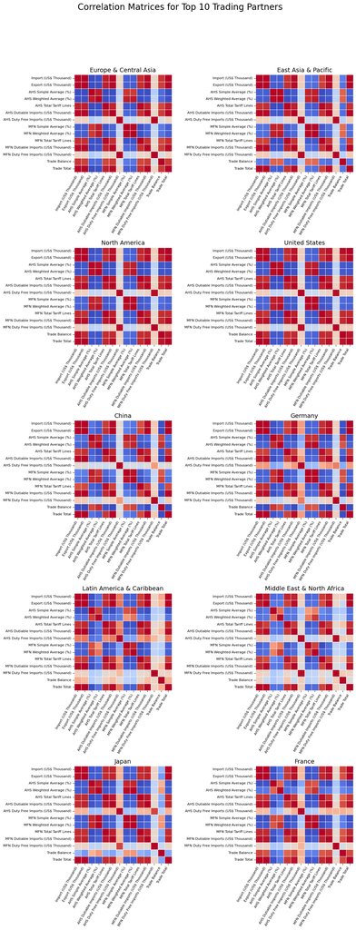

```python
# Review of the correlation between the variables
# Create a figure with 5 rows and 2 columns (10 subplots total) for the top 10 partners

# Get a list of all numeric column names (excluding 'Year' if you wish)
numeric_columns = filtered_data.select_dtypes(include='number').columns.tolist()
# Remove 'Year' if you don't want to include it in the correlation
numeric_columns = [col for col in numeric_columns if col != 'Year']

fig, axes = plt.subplots(5, 2, figsize=(12, 30))  # Larger size for better readability
axes = axes.flatten()  # Convert 2D array of axes to 1D for easier iteration

# Loop through each of the top 10 trading partners
for i, partner in enumerate(top_10_partners):
    # Filter data for the current partner and select only numeric columns
    partner_data = filtered_data[filtered_data['Partner Name'] == partner][numeric_columns].dropna()

    # Only create a correlation matrix if we have more than 1 data point
    if len(partner_data) > 1:
        # Calculate the correlation matrix for this partner's data
        corr_matrix = partner_data.corr()

        # Create a heatmap visualization of the correlation matrix
        sns.heatmap(
            corr_matrix,
            annot=False,  # Don't show correlation values as text
            cmap='coolwarm',  # Use a blue-red color scheme
            fmt='.2f',  # Format for annotation (not used since annot=False)
            ax=axes[i],  # Place on the current subplot
            cbar=False,  # Don't show the color bar
            square=True,  # Make cells square-shaped
            linewidths=0.5  # Add thin lines between cells
        )

        # Set title and format axis labels
        axes[i].set_title(partner, fontsize=14)
        axes[i].set_xticklabels(axes[i].get_xticklabels(), rotation=60, ha='right', fontsize=8)  # Rotate x labels
        axes[i].set_yticklabels(axes[i].get_yticklabels(), rotation=0, fontsize=8)  # Keep y labels horizontal
        axes[i].tick_params(axis='both', which='major', labelsize=8)  # Set tick label size
    else:
        # If insufficient data, turn off the axis and display a message
        axes[i].axis('off')
        axes[i].set_title(f"No data\n{partner}")

# Turn off any unused subplots
for j in range(len(top_10_partners), len(axes)):
    axes[j].axis('off')

# Add an overall title to the figure
fig.suptitle('Correlation Matrices for Top 10 Trading Partners', fontsize=20, y=1.03)
plt.tight_layout(rect=[0, 0.03, 1, 0.98])  # Adjust layout to prevent overlap
plt.show()  # Display the figure
```

### Insighs with external events

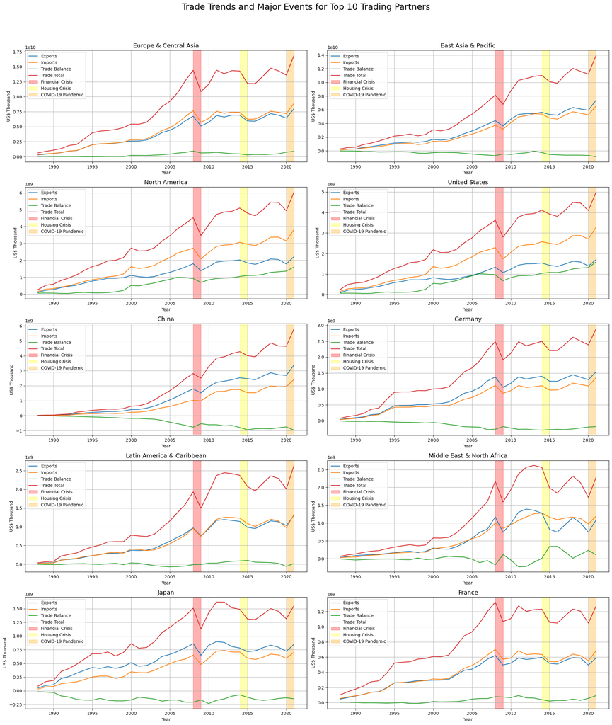

```python
# Remove "World" aggregate if needed
filtered_data = Trade_Dataset[Trade_Dataset['Partner Name'] != ' World']

# Prepare subplots: 5 rows x 2 columns for 10 partners
fig, axes = plt.subplots(5, 2, figsize=(20, 24))
axes = axes.flatten()

for i, partner in enumerate(top_10_partners):
    partner_data = filtered_data[filtered_data['Partner Name'] == partner]
    yearly_summary = partner_data.groupby('Year')[['Export (US$ Thousand)', 'Import (US$ Thousand)', 'Trade Balance', 'Trade Total']].sum()

    ax = axes[i]
    yearly_summary['Export (US$ Thousand)'].plot(ax=ax, label='Exports')
    yearly_summary['Import (US$ Thousand)'].plot(ax=ax, label='Imports')
    yearly_summary['Trade Balance'].plot(ax=ax, label='Trade Balance')
    yearly_summary['Trade Total'].plot(ax=ax, label='Trade Total')

    # Highlight global events
    ax.axvspan(2008, 2009, color='red', alpha=0.3, label='Financial Crisis')
    ax.axvspan(2014, 2015, color='yellow', alpha=0.3, label='Housing Crisis')
    ax.axvspan(2020, 2021, color='orange', alpha=0.3, label='COVID-19 Pandemic')

    ax.set_title(partner, fontsize=14)
    ax.set_xlabel("Year")
    ax.set_ylabel("US$ Thousand")
    ax.grid(True)
    ax.legend(fontsize=10)

# Remove any empty axes if fewer than 10 partners
for j in range(len(top_10_partners), len(axes)):
    axes[j].axis('off')

fig.suptitle('Trade Trends and Major Events for Top 10 Trading Partners', fontsize=20, y=1.01)
plt.tight_layout(rect=[0, 0.03, 1, 0.98])
plt.show()
```

### Case Study Part 2

June 8th, 2025

#### Dataset:

World Export & Import Dataset (1989 - 2023)

#### Source:

https://www.kaggle.com/datasets/muhammadtalhaawan/world-export-and-import-dataset

#### Phase 4 and 5: Model Building and Model Evaluation:

- Development of predictive models to address the research question and hypotheses.
- Selection of appropriate modelling techniques based on the nature of the data and research objectives.
- Rigorous evaluation of developed models using relevant metrics.
- Assessment of model performance against established benchmarks or criteria.
- Discussion of strengths, limitations, and implications of the models in addressing the research question.

### Libraries Importation

```python
# Data manipulation libraries
import os
import numpy as np
import pandas as pd

# Statistical analysis libraries
from scipy import stats
from scipy.stats import pearsonr, ttest_ind
import statsmodels.api as sm

# Machine learning libraries
from sklearn.ensemble import RandomForestRegressor
from sklearn.linear_model import LinearRegression
from sklearn.metrics import mean_absolute_error, r2_score, root_mean_squared_error
from sklearn.model_selection import train_test_split
import joblib

# Visualization libraries
import matplotlib.pyplot as plt
import seaborn as sns
```

### Import Dataset

```python
# Load the world export-import dataset from a CSV file into a pandas DataFrame
dts_export_import = pd.read_csv('34_years_world_export_import_dataset.csv')
```

### Initial Filter with the countries to analyze

```python
# Define a list of major trading partners to focus analysis on
partners = [
    'China',
    'United States',
    'Germany',
    'Japan',
    'France',
    'United Kingdom',
    'Switzerland',
    'Turkey',
    'Netherlands'
]

# Filter the trade dataset to include only the specified partners
# Exclude 'World' aggregate data and keep only rows where Partner Name is in our list
filtered_data = dts_export_import[
    (dts_export_import['Partner Name'] != ' World') &
    (dts_export_import['Partner Name'].isin(partners))
]
```

### Creation and preprocessing of the work dataset

```python
# Create a new dataframe with selected columns from filtered_data
Trade_Dataset = filtered_data[[
'Partner Name',
'Year',
'Export (US$ Thousand)',
'Import (US$ Thousand)',
'AHS Total Tariff Lines',
'MFN Total Tariff Lines',
'AHS Duty Free Tariff Lines Share (%)'
]].copy()

# Calculate trade balance (exports minus imports)
Trade_Dataset['Trade Balance'] = Trade_Dataset['Export (US$ Thousand)'] - Trade_Dataset['Import (US$ Thousand)']
# Calculate total trade volume (exports plus imports)
Trade_Dataset['Trade Total'] = Trade_Dataset['Export (US$ Thousand)'] + Trade_Dataset['Import (US$ Thousand)']

# Remove rows with missing values
Trade_Dataset = Trade_Dataset.dropna()

# Remove duplicate rows from the dataset
Trade_Dataset = Trade_Dataset.drop_duplicates()
```

```python
### Swapping Columns for Export and Import detected in the exploration
```

```python
# From the last calculations and graphs, the values for imports and exports seem inverted.
# We review the source and we found a error in the generation of the data, for this reason we interchange the
# columns names
# Create a mapping for swapping column names
swap_dict = {
    'Export (US$ Thousand)': 'Import (US$ Thousand)',
    'Import (US$ Thousand)': 'Export (US$ Thousand)'
}

# Temporarily rename to avoid conflicts, then assign back the original names swapped
Trade_Dataset = Trade_Dataset.rename(columns={
    'Export (US$ Thousand)': 'TEMP_EXPORT',
    'Import (US$ Thousand)': 'Export (US$ Thousand)'
})
Trade_Dataset = Trade_Dataset.rename(columns={
    'TEMP_EXPORT': 'Import (US$ Thousand)'
})
```

### Checking and handling outliers for each country separately

```python
def remove_iqr_outliers(df, columns):
    """
    Remove outliers from dataframe using the Interquartile Range (IQR) method.

    Args:
        df (DataFrame): Input dataframe
        columns (list): List of column names to check for outliers

    Returns:
        DataFrame: Dataframe with outliers removed
    """
    for col in columns:
        # Calculate first quartile (25th percentile)
        Q1 = df[col].quantile(0.25)
        # Calculate third quartile (75th percentile)
        Q3 = df[col].quantile(0.75)
        # Calculate interquartile range
        IQR = Q3 - Q1
        # Define lower and upper bounds for outliers (1.5 * IQR rule)
        lower_bound = Q1 - 1.5 * IQR
        upper_bound = Q3 + 1.5 * IQR
        # Filter dataframe to keep only values within bounds
        df = df[(df[col] >= lower_bound) & (df[col] <= upper_bound)]
    return df

def remove_zscore_outliers(df, columns, threshold=3):
    """
    Remove outliers from dataframe using the Z-score method.

    Args:
        df (DataFrame): Input dataframe
        columns (list): List of column names to check for outliers
        threshold (float): Z-score threshold (default: 3)

    Returns:
        DataFrame: Dataframe with outliers removed
    """
    # Calculate absolute Z-scores for specified columns
    z_scores = np.abs(stats.zscore(df[columns]))
    # Create mask where all Z-scores are below threshold
    mask = (z_scores < threshold).all(axis=1)
    # Return filtered dataframe
    return df[mask]

# Define numeric columns to check for outliers
numeric_cols = [
    'Export (US$ Thousand)',
    'Import (US$ Thousand)',
    'AHS Total Tariff Lines',
    'MFN Total Tariff Lines',
    'AHS Duty Free Tariff Lines Share (%)',
    'Trade Balance',
    'Trade Total'
]

# List to store cleaned dataframes for each partner
all_cleaned = []

# Process each partner separately
for partner in partners:
    # Filter data for current partner
    partner_data = Trade_Dataset[Trade_Dataset['Partner Name'] == partner]
    print("Shape before outlier removal:"+ partner +" "+ str(partner_data.shape))

    # Apply two-stage outlier removal process
    # First remove IQR outliers
    cleaned_iqr = remove_iqr_outliers(partner_data, numeric_cols)
    # Then remove Z-score outliers from the IQR-cleaned data
    cleaned_zscore = remove_zscore_outliers(cleaned_iqr, numeric_cols)
    # Add cleaned partner data to our collection
    all_cleaned.append(cleaned_zscore)

    print("Shape after outlier removal:"+ partner +" "+str(cleaned_zscore.shape))

# Combine all cleaned partner dataframes into a single dataframe
Trade_Dataset_no_outliers = pd.concat(all_cleaned, ignore_index=True)

print("Shape after outlier removal (all partners combined):", Trade_Dataset_no_outliers.shape)
```

```
Shape before outlier removal:China (34, 9)
Shape after outlier removal:China (28, 9)
Shape before outlier removal:United States (34, 9)
Shape after outlier removal:United States (34, 9)
Shape before outlier removal:Germany (34, 9)
Shape after outlier removal:Germany (34, 9)
Shape before outlier removal:Japan (34, 9)
Shape after outlier removal:Japan (29, 9)
Shape before outlier removal:France (34, 9)
Shape after outlier removal:France (34, 9)
Shape before outlier removal:United Kingdom (34, 9)
Shape after outlier removal:United Kingdom (31, 9)
Shape before outlier removal:Switzerland (34, 9)
Shape after outlier removal:Switzerland (34, 9)
Shape before outlier removal:Turkey (34, 9)
Shape after outlier removal:Turkey (34, 9)
Shape before outlier removal:Netherlands (34, 9)
Shape after outlier removal:Netherlands (34, 9)
Shape after outlier removal (all partners combined): (292, 9)
```

#### H1: A country’s average tariff rates (AHS and MFN) and its trade balance (exports minus imports) from 1988 to 2021 have a statistically significant negative correlation

Pearson correlation for initial analysis, followed by linear regression to model the relationship. Linear regression is suitable for interpretability and continuous outcomes

This code iterates over a list of partner countries, and for each one, it analyzes the relationship between tariff rates and trade balance by calculating Pearson correlations, performing a linear regression, and visualizing the results with a regression plot.

```
==========================================
Partner: China
Pearson Correlation:
  AHS Total Tariff Lines vs Trade Balance: r = -0.933, p = 0.000
  MFN Total Tariff Lines vs Trade Balance: r = -0.860, p = 0.000

--- Regression Analysis: AHS Total Tariff Lines vs Trade Balance ---
Validation:
  RMSE: 84645061.39
  MAE: 60266570.44
  R^2: 0.950
Test:
  RMSE: 146732519.70
  MAE: 128542684.28
  R^2: 0.792
Model saved as H1_Regression_Models/China_ahs_total_tariff_lines_model.joblib
```

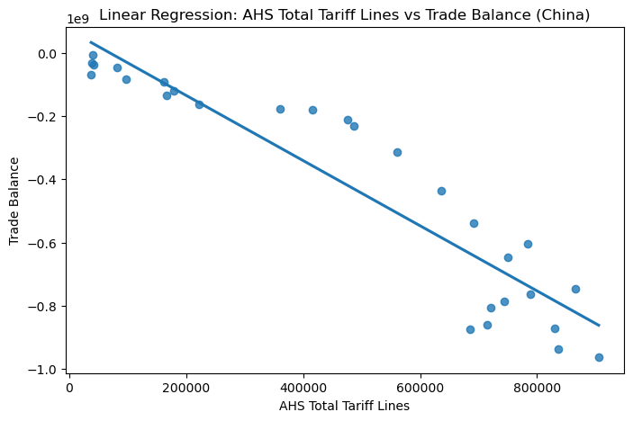

```
--- Regression Analysis: MFN Total Tariff Lines vs Trade Balance ---
Validation:
  RMSE: 106451786.33
  MAE: 77614268.99
  R^2: 0.921
Test:
  RMSE: 250576920.62
  MAE: 223969315.14
  R^2: 0.394
Model saved as H1_Regression_Models/China_mfn_total_tariff_lines_model.joblib
```

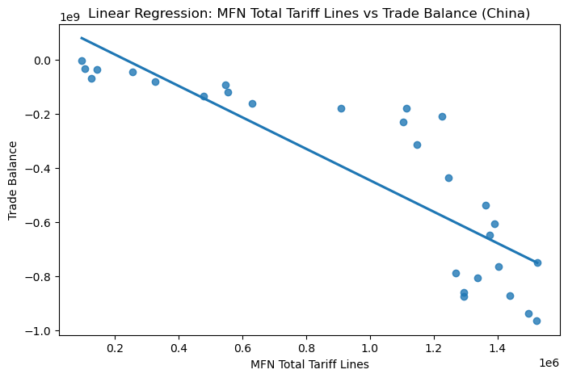

```
==========================================
Partner: United States
Pearson Correlation:
  AHS Total Tariff Lines vs Trade Balance: r = 0.919, p = 0.000
  MFN Total Tariff Lines vs Trade Balance: r = 0.925, p = 0.000

--- Regression Analysis: AHS Total Tariff Lines vs Trade Balance ---
Validation:
  RMSE: 223957365.13
  MAE: 207919742.82
  R^2: 0.708
Test:
  RMSE: 125986483.37
  MAE: 107486890.95
  R^2: 0.905
Model saved as H1_Regression_Models/United_States_ahs_total_tariff_lines_model.joblib
```

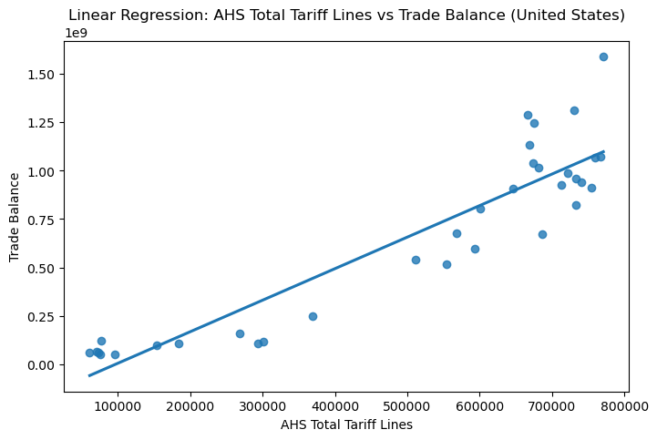

```
--- Regression Analysis: MFN Total Tariff Lines vs Trade Balance ---
Validation:
  RMSE: 199587841.23
  MAE: 182883606.35
  R^2: 0.768
Test:
  RMSE: 129671040.71
  MAE: 110860495.82
  R^2: 0.899
Model saved as H1_Regression_Models/United_States_mfn_total_tariff_lines_model.joblib
```

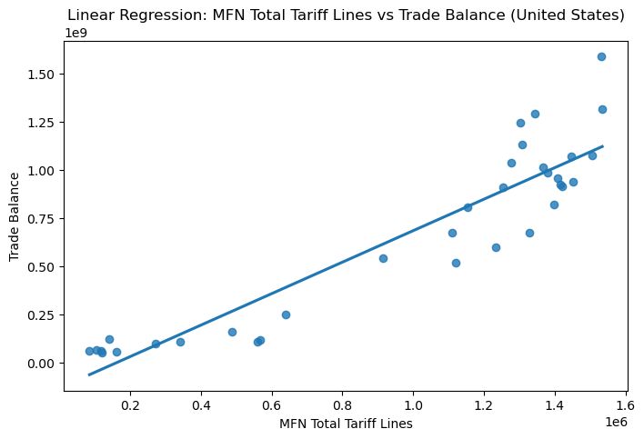

```
==========================================
Partner: Germany
Pearson Correlation:
  AHS Total Tariff Lines vs Trade Balance: r = -0.837, p = 0.000
  MFN Total Tariff Lines vs Trade Balance: r = -0.904, p = 0.000

--- Regression Analysis: AHS Total Tariff Lines vs Trade Balance ---
Validation:
  RMSE: 73857598.36
  MAE: 65589302.58
  R^2: 0.367
Test:
  RMSE: 52890439.96
  MAE: 48340094.99
  R^2: 0.775
Model saved as H1_Regression_Models/Germany_ahs_total_tariff_lines_model.joblib
```

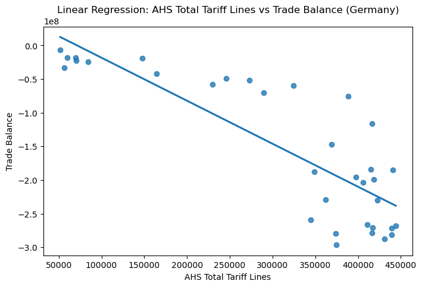

```
--- Regression Analysis: MFN Total Tariff Lines vs Trade Balance ---
Validation:
  RMSE: 64038989.78
  MAE: 59361187.43
  R^2: 0.524
Test:
  RMSE: 35117752.99
  MAE: 32088501.13
  R^2: 0.901
Model saved as H1_Regression_Models/Germany_mfn_total_tariff_lines_model.joblib
```

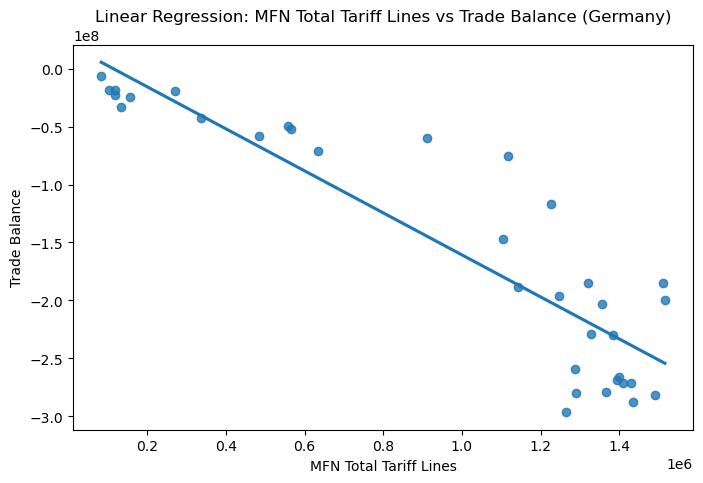

```
==========================================
Partner: Japan
Pearson Correlation:
  AHS Total Tariff Lines vs Trade Balance: r = -0.164, p = 0.395
  MFN Total Tariff Lines vs Trade Balance: r = -0.129, p = 0.506

--- Regression Analysis: AHS Total Tariff Lines vs Trade Balance ---
Validation:
  RMSE: 35001625.96
  MAE: 27896861.29
  R^2: -0.285
Test:
  RMSE: 34633329.90
  MAE: 26707419.36
  R^2: 0.130
Model saved as H1_Regression_Models/Japan_ahs_total_tariff_lines_model.joblib
```

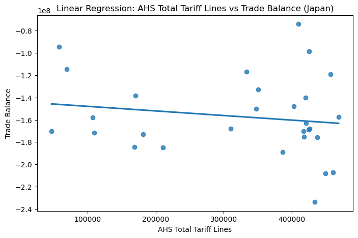

```
--- Regression Analysis: MFN Total Tariff Lines vs Trade Balance ---
Validation:
  RMSE: 34765627.28
  MAE: 27667334.22
  R^2: -0.268
Test:
  RMSE: 35420305.64
  MAE: 27507690.76
  R^2: 0.090
Model saved as H1_Regression_Models/Japan_mfn_total_tariff_lines_model.joblib
```

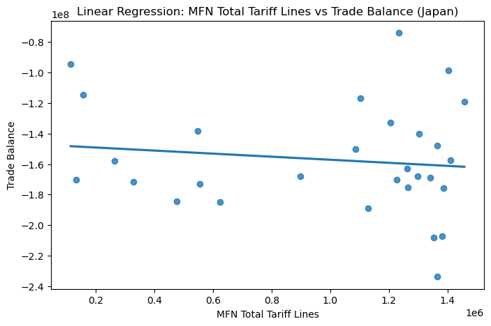

```
==========================================
Partner: France
Pearson Correlation:
  AHS Total Tariff Lines vs Trade Balance: r = 0.745, p = 0.000
  MFN Total Tariff Lines vs Trade Balance: r = 0.789, p = 0.000

--- Regression Analysis: AHS Total Tariff Lines vs Trade Balance ---
Validation:
  RMSE: 15165415.22
  MAE: 13104652.95
  R^2: 0.680
Test:
  RMSE: 24459007.10
  MAE: 22372128.52
  R^2: 0.116
Model saved as H1_Regression_Models/France_ahs_total_tariff_lines_model.joblib
```

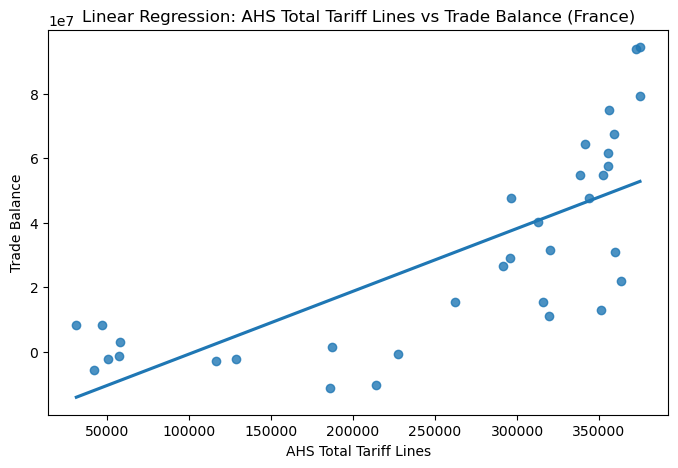

```
--- Regression Analysis: MFN Total Tariff Lines vs Trade Balance ---
Validation:
  RMSE: 14204233.60
  MAE: 11495604.18
  R^2: 0.719
Test:
  RMSE: 21763363.94
  MAE: 19245940.64
  R^2: 0.300
Model saved as H1_Regression_Models/France_mfn_total_tariff_lines_model.joblib
```

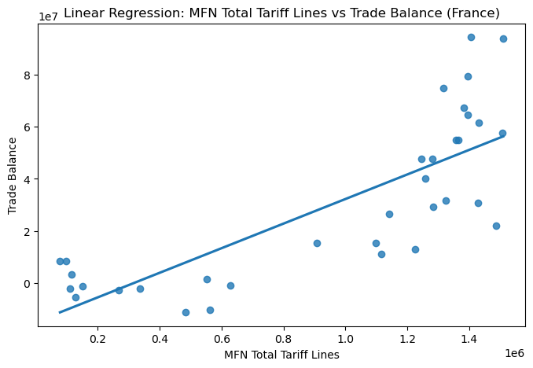

```
==========================================
Partner: United Kingdom
Pearson Correlation:
  AHS Total Tariff Lines vs Trade Balance: r = 0.791, p = 0.000
  MFN Total Tariff Lines vs Trade Balance: r = 0.883, p = 0.000

--- Regression Analysis: AHS Total Tariff Lines vs Trade Balance ---
Validation:
  RMSE: 50333250.30
  MAE: 44990410.98
  R^2: 0.615
Test:
  RMSE: 54663416.64
  MAE: 44193391.15
  R^2: 0.383
Model saved as H1_Regression_Models/United_Kingdom_ahs_total_tariff_lines_model.joblib
```

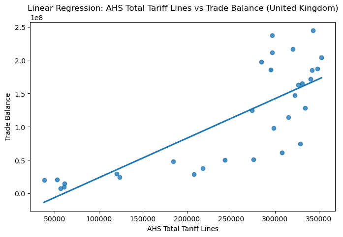

```
--- Regression Analysis: MFN Total Tariff Lines vs Trade Balance ---
Validation:
  RMSE: 31429428.59
  MAE: 30127128.86
  R^2: 0.850
Test:
  RMSE: 50179581.74
  MAE: 41062729.83
  R^2: 0.480
Model saved as H1_Regression_Models/United_Kingdom_mfn_total_tariff_lines_model.joblib
```

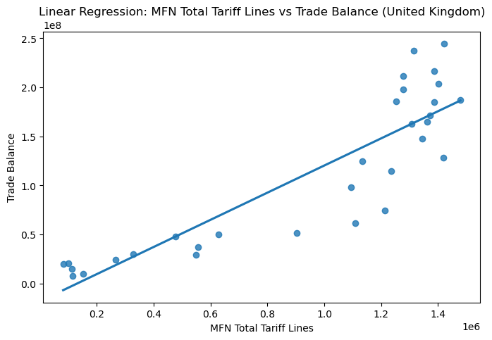

```
==========================================
Partner: Switzerland
Pearson Correlation:
  AHS Total Tariff Lines vs Trade Balance: r = 0.944, p = 0.000
  MFN Total Tariff Lines vs Trade Balance: r = 0.925, p = 0.000

--- Regression Analysis: AHS Total Tariff Lines vs Trade Balance ---
Validation:
  RMSE: 11945592.94
  MAE: 8897050.31
  R^2: 0.946
Test:
  RMSE: 22174000.95
  MAE: 21019654.67
  R^2: 0.869
Model saved as H1_Regression_Models/Switzerland_ahs_total_tariff_lines_model.joblib
```

[6 more figures not shown]

```python
os.makedirs("H1_Regression_Models", exist_ok=True)  # Create a directory for saved models
for i, partner in enumerate(partners):
    # Filter dataset for the current partner
    partner_data = Trade_Dataset_no_outliers[Trade_Dataset_no_outliers['Partner Name'] == partner]

    # Define columns for tariff analysis
    tariff_cols = ['AHS Total Tariff Lines', 'MFN Total Tariff Lines']
    trade_balance_col = 'Trade Balance'

    print("\n==========================================")
    print(f"Partner: {partner}")

    # Pearson Correlations
    print("Pearson Correlation:")
    for col in tariff_cols:
        corr, pval = pearsonr(partner_data[col], partner_data[trade_balance_col])
        print(f"  {col} vs Trade Balance: r = {corr:.3f}, p = {pval:.3f}")

    for col in tariff_cols:
        print(f"\n--- Regression Analysis: {col} vs Trade Balance ---")
        X = partner_data[[col]]
        y = partner_data[trade_balance_col]

        # Train/Val/Test Split
        X_train, X_temp, y_train, y_temp = train_test_split(X, y, test_size=0.3, random_state=42)
        X_val, X_test, y_val, y_test = train_test_split(X_temp, y_temp, test_size=0.5, random_state=42)

        # Fit Linear Regression
        model = LinearRegression().fit(X_train, y_train)

        # Evaluation on Validation set
        y_pred_val = model.predict(X_val)
        print("Validation:")
        print(f"  RMSE: {root_mean_squared_error(y_val, y_pred_val):.2f}")
        print(f"  MAE: {mean_absolute_error(y_val, y_pred_val):.2f}")
        print(f"  R^2: {r2_score(y_val, y_pred_val):.3f}")

        # Final Test set evaluation
        y_pred_test = model.predict(X_test)
        print("Test:")
        print(f"  RMSE: {root_mean_squared_error(y_test, y_pred_test):.2f}")
        print(f"  MAE: {mean_absolute_error(y_test, y_pred_test):.2f}")
        print(f"  R^2: {r2_score(y_test, y_pred_test):.3f}")

        # Save model
        model_filename = f"H1_Regression_Models/{partner.replace(' ', '_')}_{col.replace(' ', '_').lower()}_model.joblib"
        joblib.dump(model, model_filename)
        print(f"Model saved as {model_filename}")

        # Visualization
        plt.figure(figsize=(8,5))
        sns.regplot(x=col, y=trade_balance_col, data=partner_data, ci=None)
        plt.title(f"Linear Regression: {col} vs Trade Balance ({partner})")
        plt.xlabel(col)
        plt.ylabel("Trade Balance")
        plt.show()
```

#### H2: Countries with a higher proportion of duty-free tariff lines have significantly higher export volumes compared to countries with lower duty-free shares.

Random Forest Regressor to capture potential non-linear relationships between duty-free share and export volumes, as trade data often exhibits complex patterns.

This code loops through each partner country and uses a Random Forest regression model to predict export volumes based on the share of duty-free tariff lines, evaluating model performance with metrics, visualizing the results, and displaying feature importance.

```
Random Forest Analysis for: China
Validation Set:
  RMSE: 1759556447.74
  MAE: 1508054601.90
  R^2: -1.470
Test Set:
  RMSE: 460812398.23
  MAE: 374897786.43
  R^2: -2.150
```

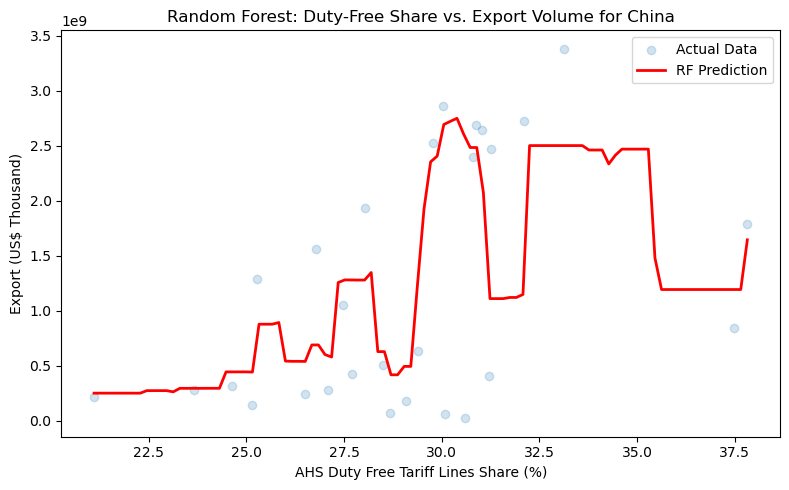

```
  Feature Importance: [1.]
  Model saved to H2_RandomForest_models/China_rf_model.joblib

Random Forest Analysis for: United States
Validation Set:
  RMSE: 315896653.62
  MAE: 283219389.53
  R^2: 0.439
Test Set:
  RMSE: 234934711.71
  MAE: 174679659.92
  R^2: 0.670
```

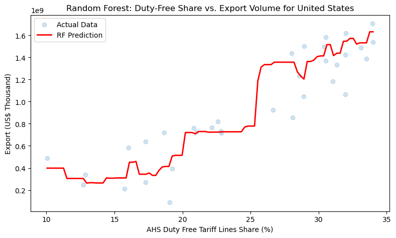

```
  Feature Importance: [1.]
  Model saved to H2_RandomForest_models/United_States_rf_model.joblib

Random Forest Analysis for: Germany
Validation Set:
  RMSE: 434334918.17
  MAE: 224479733.05
  R^2: 0.050
Test Set:
  RMSE: 157521001.29
  MAE: 138489918.04
  R^2: 0.849
```

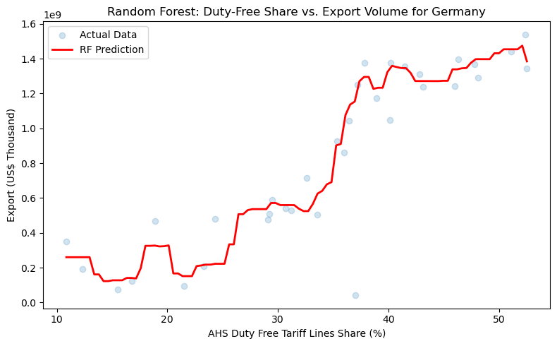

```
  Feature Importance: [1.]
  Model saved to H2_RandomForest_models/Germany_rf_model.joblib

Random Forest Analysis for: Japan
Validation Set:
  RMSE: 94039635.34
  MAE: 79827423.60
  R^2: 0.846
Test Set:
  RMSE: 67315906.28
  MAE: 56729710.03
  R^2: 0.697
```

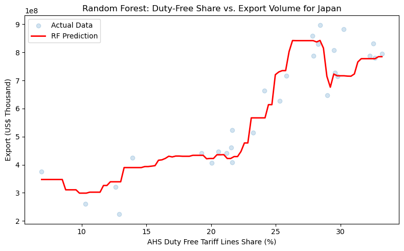

```
  Feature Importance: [1.]
  Model saved to H2_RandomForest_models/Japan_rf_model.joblib

Random Forest Analysis for: France
Validation Set:
  RMSE: 189758577.18
  MAE: 106995583.94
  R^2: -0.088
Test Set:
  RMSE: 72876502.95
  MAE: 66371251.46
  R^2: 0.730
```

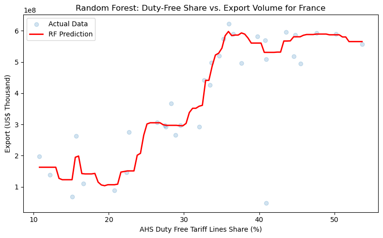

```
  Feature Importance: [1.]
  Model saved to H2_RandomForest_models/France_rf_model.joblib

Random Forest Analysis for: United Kingdom
Validation Set:
  RMSE: 62899910.47
  MAE: 54005123.44
  R^2: 0.829
Test Set:
  RMSE: 168420048.35
  MAE: 121907498.44
  R^2: -0.890
```

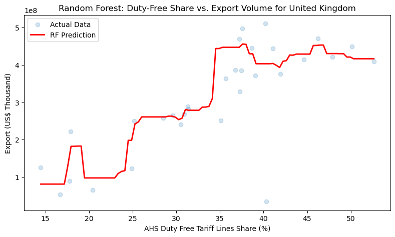

```
  Feature Importance: [1.]
  Model saved to H2_RandomForest_models/United_Kingdom_rf_model.joblib

Random Forest Analysis for: Switzerland
Validation Set:
  RMSE: 71425083.88
  MAE: 58213545.54
  R^2: 0.412
Test Set:
  RMSE: 38389412.39
  MAE: 27626667.72
  R^2: 0.878
```

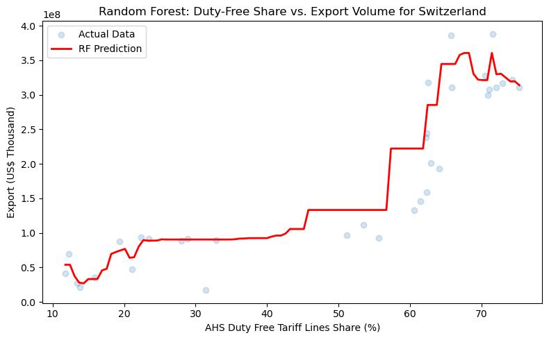

```
  Feature Importance: [1.]
  Model saved to H2_RandomForest_models/Switzerland_rf_model.joblib

Random Forest Analysis for: Turkey
Validation Set:
  RMSE: 44462998.95
  MAE: 37098555.76
  R^2: 0.156
Test Set:
  RMSE: 37926189.39
  MAE: 27765489.57
  R^2: 0.530
```

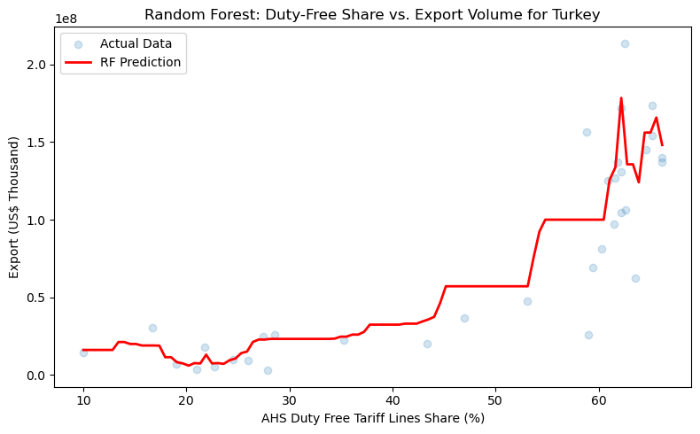

```
  Feature Importance: [1.]
  Model saved to H2_RandomForest_models/Turkey_rf_model.joblib

Random Forest Analysis for: Netherlands
Validation Set:
  RMSE: 171980037.21
  MAE: 97588430.07
  R^2: -0.322
Test Set:
  RMSE: 75876798.72
  MAE: 62119762.08
  R^2: 0.730
```

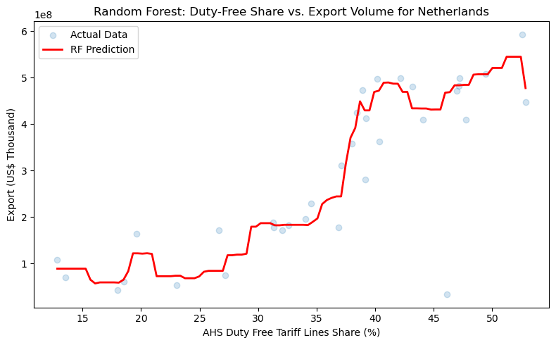

```
  Feature Importance: [1.]
  Model saved to H2_RandomForest_models/Netherlands_rf_model.joblib
```

```python
os.makedirs("H2_RandomForest_models", exist_ok=True)

for i, partner in enumerate(partners):
    # Filter dataset for the current partner
    partner_data = Trade_Dataset_no_outliers[Trade_Dataset_no_outliers['Partner Name'] == partner]

    # Prepare features (X) and target variable (y)
    X = partner_data[['AHS Duty Free Tariff Lines Share (%)']].values
    y = partner_data['Export (US$ Thousand)'].values

    # Split data: first train/test+val, then split test+val into test and val
    X_train, X_temp, y_train, y_temp = train_test_split(X, y, test_size=0.4, random_state=42)
    X_val, X_test, y_val, y_test = train_test_split(X_temp, y_temp, test_size=0.5, random_state=42)
    # Now: 60% train, 20% val, 20% test

    # Initialize and train Random Forest Regressor model
    rf = RandomForestRegressor(n_estimators=100, random_state=42)
    rf.fit(X_train, y_train)

    # Make predictions for validation and test sets
    y_pred_val = rf.predict(X_val)
    y_pred_test = rf.predict(X_test)

    # Evaluate model performance (validation)
    val_rmse = root_mean_squared_error(y_val, y_pred_val)
    val_mae = mean_absolute_error(y_val, y_pred_val)
    val_r2 = r2_score(y_val, y_pred_val)

    # Evaluate model performance (test)
    test_rmse = root_mean_squared_error(y_test, y_pred_test)
    test_mae = mean_absolute_error(y_test, y_pred_test)
    test_r2 = r2_score(y_test, y_pred_test)

    print(f"\nRandom Forest Analysis for: {partner}")
    print("Validation Set:")
    print(f"  RMSE: {val_rmse:.2f}")
    print(f"  MAE: {val_mae:.2f}")
    print(f"  R^2: {val_r2:.3f}")
    print("Test Set:")
    print(f"  RMSE: {test_rmse:.2f}")
    print(f"  MAE: {test_mae:.2f}")
    print(f"  R^2: {test_r2:.3f}")

    # Generate prediction line across the range of duty-free percentages
    duty_free_range = np.linspace(
        partner_data['AHS Duty Free Tariff Lines Share (%)'].min(),
        partner_data['AHS Duty Free Tariff Lines Share (%)'].max(),
        100
    ).reshape(-1, 1)
    predicted_exports = rf.predict(duty_free_range)

    # Visualization
    plt.figure(figsize=(8,5))
    plt.scatter(X, y, alpha=0.2, label='Actual Data')
    plt.plot(duty_free_range, predicted_exports, color='red', linewidth=2, label='RF Prediction')
    plt.xlabel('AHS Duty Free Tariff Lines Share (%)')
    plt.ylabel('Export (US$ Thousand)')
    plt.title(f'Random Forest: Duty-Free Share vs. Export Volume for {partner}')
    plt.legend()
    plt.tight_layout()
    plt.show()

    # Feature importance
    print("  Feature Importance:", rf.feature_importances_)

    # Save the model
    model_path = f"H2_RandomForest_models/{partner.replace(' ', '_').replace('/', '_')}_rf_model.joblib"
    joblib.dump(rf, model_path)
    print(f"  Model saved to {model_path}")
```

#### H3: Major global events (such as financial crises and pandemics) are associated with statistically significant changes in global trade volumes, as observed in year-over-year export and import data

T-test to compare trade volumes during event vs. non-event periods, supplemented by visualization (boxplot) for intuitive insights.

This code labels each year in the dataset according to major global events, then compares trade indicators (export, import, trade balance, and total trade) between event and non-event periods using T-tests and boxplots to visualize the impact of these events on trade volumes.

```
T-test statistic: 3.726
P-value: 0.0005
```

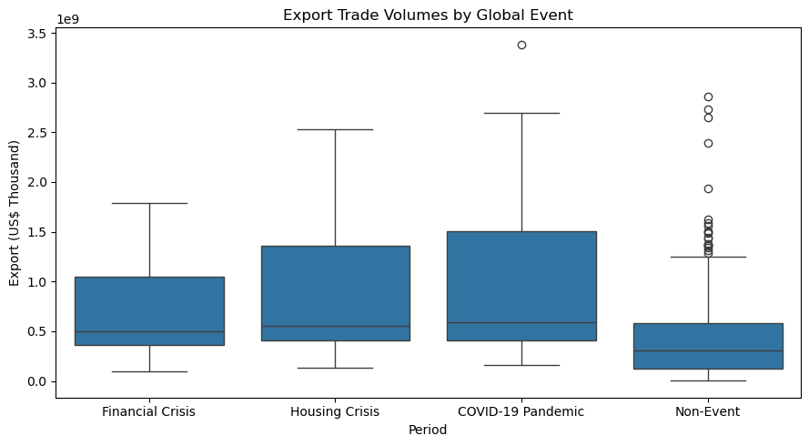

```
T-test statistic: 3.981
P-value: 0.0002
```

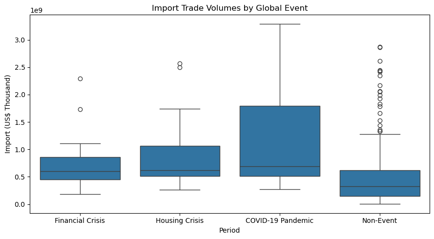

```
T-test statistic: 0.517
P-value: 0.6075
```

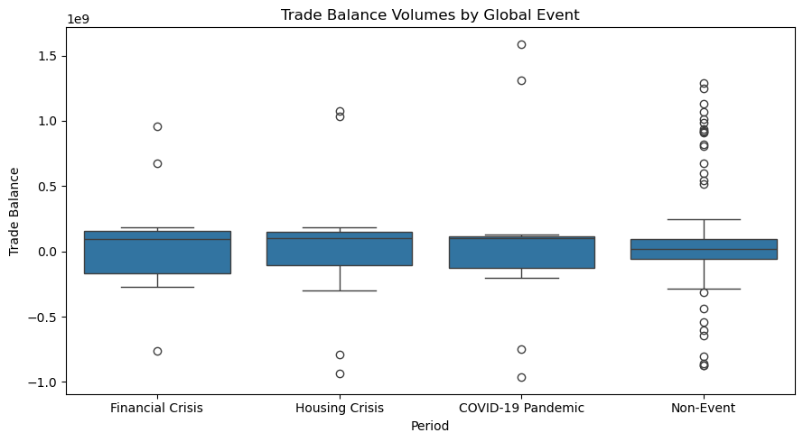

```
T-test statistic: 4.082
P-value: 0.0001
```

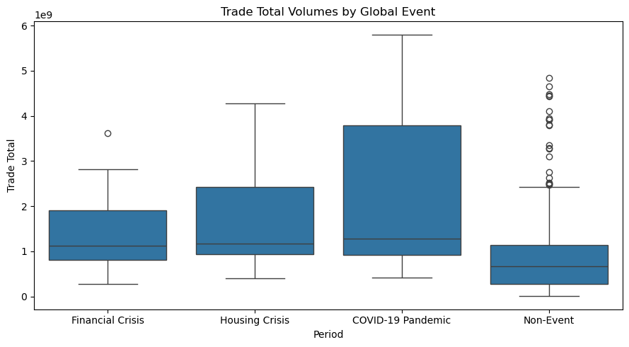

```python
# Map years to event names
event_dict = {
    2008: 'Financial Crisis',
    2009: 'Financial Crisis',
    2014: 'Housing Crisis',
    2015: 'Housing Crisis',
    2020: 'COVID-19 Pandemic',
    2021: 'COVID-19 Pandemic'
}

# Create 'Global Event' column
Trade_Dataset_no_outliers['Global Event'] = Trade_Dataset_no_outliers['Year'].map(event_dict).fillna('Non-Event')

# Create binary column for T-test: 1 if event, 0 if non-event
Trade_Dataset_no_outliers['Is Event'] = Trade_Dataset_no_outliers['Global Event'].apply(lambda x: 0 if x == 'Non-Event' else 1)

trade_col = 'Export (US$ Thousand)'

# Split data
event_trades = Trade_Dataset_no_outliers[Trade_Dataset_no_outliers['Is Event'] == 1][trade_col].dropna()
non_event_trades = Trade_Dataset_no_outliers[Trade_Dataset_no_outliers['Is Event'] == 0][trade_col].dropna()

# T-test (Welch's)
t_stat, p_val = ttest_ind(event_trades, non_event_trades, equal_var=False)
print(f"T-test statistic: {t_stat:.3f}")
print(f"P-value: {p_val:.4f}")

# Boxplot by event group
plt.figure(figsize=(9,5))
sns.boxplot(x='Global Event', y=trade_col, data=Trade_Dataset_no_outliers, order=['Financial Crisis', 'Housing Crisis', 'COVID-19 Pandemic', 'Non-Event'])
plt.ylabel(trade_col)
plt.xlabel('Period')
plt.title('Export Trade Volumes by Global Event')
plt.tight_layout()
plt.show()

trade_col = 'Import (US$ Thousand)'

# Split data
event_trades = Trade_Dataset_no_outliers[Trade_Dataset_no_outliers['Is Event'] == 1][trade_col].dropna()
non_event_trades = Trade_Dataset_no_outliers[Trade_Dataset_no_outliers['Is Event'] == 0][trade_col].dropna()

# T-test (Welch's)
t_stat, p_val = ttest_ind(event_trades, non_event_trades, equal_var=False)
print(f"T-test statistic: {t_stat:.3f}")
print(f"P-value: {p_val:.4f}")

# Boxplot by event group
plt.figure(figsize=(9,5))
sns.boxplot(x='Global Event', y=trade_col, data=Trade_Dataset_no_outliers, order=['Financial Crisis', 'Housing Crisis', 'COVID-19 Pandemic', 'Non-Event'])
plt.ylabel(trade_col)
plt.xlabel('Period')
plt.title('Import Trade Volumes by Global Event')
plt.tight_layout()
plt.show()

trade_col = 'Trade Balance'

# Split data
event_trades = Trade_Dataset_no_outliers[Trade_Dataset_no_outliers['Is Event'] == 1][trade_col].dropna()
non_event_trades = Trade_Dataset_no_outliers[Trade_Dataset_no_outliers['Is Event'] == 0][trade_col].dropna()

# T-test (Welch's)
t_stat, p_val = ttest_ind(event_trades, non_event_trades, equal_var=False)
print(f"T-test statistic: {t_stat:.3f}")
print(f"P-value: {p_val:.4f}")

# Boxplot by event group
plt.figure(figsize=(9,5))
sns.boxplot(x='Global Event', y=trade_col, data=Trade_Dataset_no_outliers, order=['Financial Crisis', 'Housing Crisis', 'COVID-19 Pandemic', 'Non-Event'])
plt.ylabel(trade_col)
plt.xlabel('Period')
plt.title('Trade Balance Volumes by Global Event')
plt.tight_layout()
plt.show()


trade_col = 'Trade Total'

# Split data
event_trades = Trade_Dataset_no_outliers[Trade_Dataset_no_outliers['Is Event'] == 1][trade_col].dropna()
non_event_trades = Trade_Dataset_no_outliers[Trade_Dataset_no_outliers['Is Event'] == 0][trade_col].dropna()

# T-test (Welch's)
t_stat, p_val = ttest_ind(event_trades, non_event_trades, equal_var=False)
print(f"T-test statistic: {t_stat:.3f}")
print(f"P-value: {p_val:.4f}")

# Boxplot by event group
plt.figure(figsize=(9,5))
sns.boxplot(x='Global Event', y=trade_col, data=Trade_Dataset_no_outliers, order=['Financial Crisis', 'Housing Crisis', 'COVID-19 Pandemic', 'Non-Event'])
plt.ylabel(trade_col)
plt.xlabel('Period')
plt.title('Trade Total Volumes by Global Event')
plt.tight_layout()
plt.show()
```